# exercise 5

hyojunahn

2017년 11월 29일

## 5.4

## 5.4.a

### We now review k-fold cross-validation.

### (a) Explain how k-fold cross-validation is implemented.

> 1. 무작위로 데이터를 k개의 fold (겹, ex> 여러겹) 로 나눕니다. 즉 100개를 k 개의 집단으로 무작위로 나눕니다.
> 2. 각 집단 중 하나의 집단이 test set이 되고 나머지는 학습을 위한 데이터로 진행합니다.
> 3. 학습한 모델을 기준으로 test set으로 평가한 error를 기록합니다.
> 4. 이것을 돌아가면서 k번 실시합니다.
> 5. 기록한 error를 평균을 내고 그것을 cross-validation error라고 칭하고, 모델을 평가하는 하나의 지표로 활용합니다

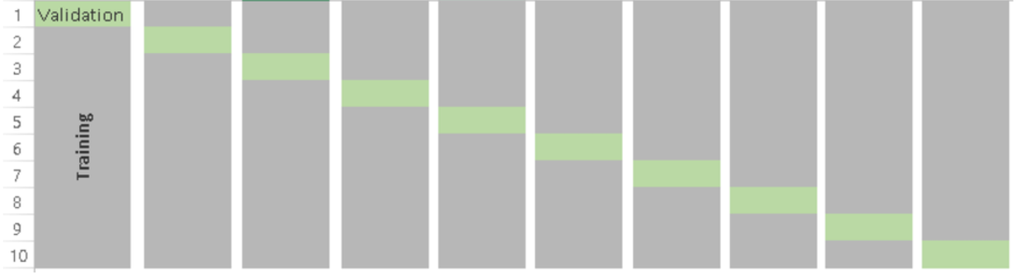

## 5.4.b What are the advantages and disadvantages of k-fold crossvalidation relative to:i. The validation set approach? ii. LOOCV?

### 1. The validation set Approach

> 이방법은 50%의 data 는 검증을 위해 남기고, 다른 50%는 모델 학습을 위해서 남겨놓습니다. 모델 학습후 모델 검증은 validation data를 가지고 합니다. (보통은 50:50도 많이 하지만 70:30 도 하는경우도 있고 둘다 the validation set approach라고 이야기 할수 있습니다.)

#### 단점

```
1. 일부의 데이터만 학습을 하기 때문에 모델이 일부 데이터를 설명하기에는 부족하지 않겠지만 경우에 따라 전체 데이터를 설명하는데는 부족한 모델이 될수 있다.

이것을 통계적 용어로 "bias 가 높다"고 할수 있는데 , 경우에 따라 일부 데이터로만 학습하였기 때문에 모델이 bias가 높은 경우가 될 가능성이 높다.

즉 한국인의 한달 소득과 소비 값의 관계식을 파악하고자 모델을 만들었는데, 하필 학습시킨 데이터는 30대 이상이고, 검증하는 데이터는 30대 이하일 경우, 30대 이상의 데이터로 만 학습하게 되면 전체 소득과 소비 값에 대비해서  편중된 모델이 만들어질수 있다. 즉 편중된 모델이라는 것은 높은 bias 나타난다라고 이야기 할수 있고,이것은 전체를 설명하는데 부적절하다.
```

### 2. Leave one out cross validation (LOOCV)

> 이 방법은 하나의 데이터 포인트만 남기고 나머지 모든 데이터로 학습을 시켜 모델을 만드는 것입니다. 그리고 다시 다른 하나의 데이터 포인트만 남기고 나머지 모든 데이터로 학습을 시킨 후 여러번 반복해서 남겨둔 포인트들로 검증을 하는 방법입니다.

```
장점 : 거의 모든 데이터로 모델링해서 bias가 적다
단점 : 1. n번 반복시행할 경우 n배 만큼 실행시간이 길어진다.
      2. 이 방법은 모델검증에서 여러가지 다양한 결과가(즉, 높은 분산이) 발생 시킬수 있습니다.
        다시 말해서 검증을 위해서 제외시킨 하나의 data point가 예측의 큰 영향을 미치기 때문에,
        그 검증 데이터가 outlier였다면 모델은 최적의 모델이었으나, 검증 결과는 최악의 모델이 될수도 있고,
        모델은 최악의 모델이었으나 검증 결과는 최적의 모델로 검증될수도 있습니다.
```

출처: http://daryan.tistory.com/21 [Ryan의 데이터 과학 블로그]

## 5.9

## 5.9.a

```r
library(MASS)
library(boot)
attach(Boston)
mu.hat <- mean(medv)
mu.hat
```

```
## [1] 22.53281
```

## 5.9.b

```r
se.hat <- sd(medv) / sqrt(dim(Boston)[1])
se.hat
```

```
## [1] 0.4088611
```

## 5.9.c

```r
set.seed(1)
boot.fn <- function(data, index) {
    mu <- mean(data[index])
    return (mu)
}
boot(medv, boot.fn, 1000)
```

```
##
## ORDINARY NONPARAMETRIC BOOTSTRAP
##
##
## Call:
## boot(data = medv, statistic = boot.fn, R = 1000)
##
##
## Bootstrap Statistics :
##     original      bias    std. error
## t1* 22.53281 0.008517589   0.4119374
```

b의 결과와 비슷함을 볼 수 있다.

## 5.9.d

```r
t.test(medv)
```

```
##
##  One Sample t-test
##
## data:  medv
## t = 55.111, df = 505, p-value < 2.2e-16
## alternative hypothesis: true mean is not equal to 0
## 95 percent confidence interval:
##  21.72953 23.33608
## sample estimates:
## mean of x
##  22.53281
```

```r
CI.mu.hat <- c(22.53 - 2 * 0.4119, 22.53 + 2 * 0.4119)
CI.mu.hat
```

```
## [1] 21.7062 23.3538
```

신뢰구간의 범위와 t-test로 구한 것이 비슷하다.

## 5.9.e

```r
med.hat <- median(medv)
med.hat
```

```
## [1] 21.2
```

## 5.9.f

```r
boot.fn <- function(data, index) {
    mu <- median(data[index])
    return (mu)
}
boot(medv, boot.fn, 1000)
```

```
##
## ORDINARY NONPARAMETRIC BOOTSTRAP
##
##
## Call:
## boot(data = medv, statistic = boot.fn, R = 1000)
##
##
## Bootstrap Statistics :
##     original  bias    std. error
## t1*     21.2 -0.0098   0.3874004
```

e와 같은 결과이고 sd는 0.3874이다.

## 5.9.g

```r
percent.hat <- quantile(medv, c(0.1))
percent.hat
```

```
##   10%
## 12.75
```

## 5.9.h

```r
boot.fn <- function(data, index) {
    mu <- quantile(data[index], c(0.1))
    return (mu)
}
boot(medv, boot.fn, 1000)
```

```
##
## ORDINARY NONPARAMETRIC BOOTSTRAP
##
##
## Call:
## boot(data = medv, statistic = boot.fn, R = 1000)
##
##
## Bootstrap Statistics :
##     original  bias    std. error
## t1*    12.75 0.00515   0.5113487
```

12.75로 같은 결과를 보여준다.